# whatsapp

## Whatsapp Analysis

**Introduction**

This analysis is the first part of my side project of analysing my own life. Here, I analyze my whatsapp conversations and try to gain insights to improve my relationships. This starts with some basic analysis and then uses tf-idf and sentiment analysis.

Note: This analyses will always be a work in progress. As I learn more skills, I will keep updating this project.

1. Functions
2. General Statistics

   2.1 Prepare Data

   2.2 Messages over time

   2.3 Active Moments

   2.4 Averages / Summaries

   2.5 Response Time
3. TF-IDF

   3.1 Count Vector

   3.2 Unique Words

   3.3 Plot Image
4. Emoji Analysis

   4.1 Prepare Data

   4.2 Unique and Common Emojis

   4.3 Correlation Matrix
5. Sentiment Analysis

   5.1 Prepare Data

   5.2 Average Sentiment

   5.3 Plot Sentiment
6. Word Clouds

   6.1 Prepare Data

   6.2 Masked Word Cloud

   6.3 Sentiment-based Word Cloud

## 1. Functions

Back to Table of Contents

```python
from reverie.whatsapp import helper      # Helper to prepare the data
from reverie.whatsapp import general     # General statistics
from reverie.whatsapp import tf_idf      # To calculate TF-IDF
from reverie.whatsapp import emoji       # To analyze emoji use
from reverie.whatsapp import sentiment   # Sentiment Analysis
from reverie.whatsapp import wordcloud   # Create Word Clouds

%matplotlib inline
import warnings
warnings.filterwarnings("ignore")
```

## 2. General Statistics

Back to Table of Contents

Here we calculate simple statistics and get a general understanding of conversations.

#### 2.1 Prepare Data

Back to Table of Contents

The data is preprocessed by loading in the raw txt file exported from whatsapp. The following columns are created:

- Chat
  - The raw message for each user
- Date
  - Date in the format y-m-d h:m:s
- User
  - The user who has sent the message
- Message_Only_Text
  - Only text, lowercase

```python
df = helper.loadChat('whatsapp_chat.txt')
```

#### 2.2 Messages over time

Back to Table of Contents

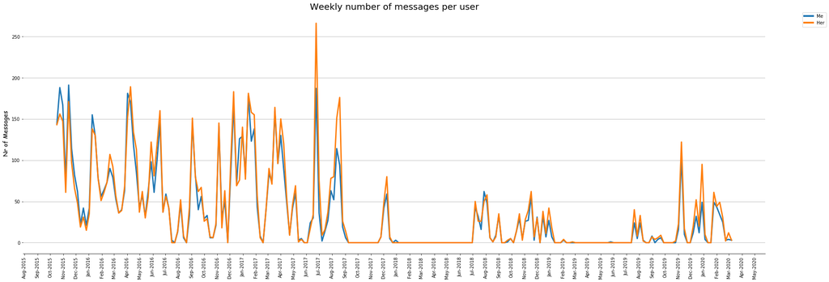

```python
general.plot_messages(df, colors=None, trendline=False, savefig=False, dpi=100)
```

#### 2.3 Active Moments

Back to Table of Contents

**Daily Activity**

This shows the daily activity per person in a spider plot.

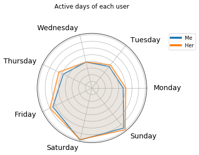

```python
general.plot_day_spider(df, colors=None, savefig=False, dpi=100)
```

**Calendar Map**

This map shows the activity for each day of a year.

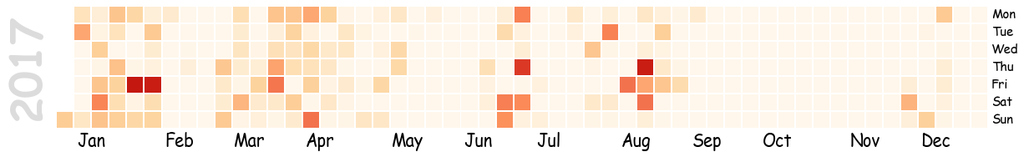

```python
general.calendar_plot(df, year=2017)
```

#### 2.4 Averages / Summaries

Back to Table of Contents

This section shows some general averages and summaries.

```python
general.print_stats(df)
```

```
##########################
##  Number of Messages  ##
##########################

7872	Me
8609	Her

#######################
##  Number of Words  ##
#######################

87189	Me
88862	Her

#########################
##  Messages per hour  ##
#########################

Me:	0.20444629129441097
Her:	0.223482685218836

################################
##  Avg nr Words per Message  ##
################################

Me: 11.08
Her: 10.32

#############################
##  Avg length of Message  ##
#############################

Me: 52.23
Her: 49.54

##############################
##  Highscore Day per User  ##
##############################

Me
Messages: 	114
Day: 		2016-12-28

Her
Messages: 	96
Day: 		2017-01-27
```

#### 2.5 Response Time

Back to Table of Contents

I have always been questioned for replying late to messages. And I always argued against it. But the data tells the truth. :D

```python
general.print_timing(df)
```

```
#####################################
##  Avg. Response Time in Minutes  ##
#####################################

Her:                          24.97
Me:                           39.2

##############################
##  Nr. Initiated Messages  ##
##############################

Me:                           89		(1.13% of all messages)
Her:                          22		(0.26% of all messages)
```

## 3. TF-IDF

Back to Table of Contents

#### 3.1 Create Count Vector

Back to Table of Contents

First create a dataframe "counts" which contains each word that is said in all conversations and counts how often each user has said that word.

```python
counts = tf_idf.count_words_per_user(df,sentence_column="Message_Only_Text",
                                     user_column="User")
counts = tf_idf.remove_stopwords(counts, path = "", file ='stopwords.txt', column="Word")
```

#### 3.2 Unique Words

Back to Table of Contents

Below you can see three version of TF-IDF.

**Version A - Messages**

$TFIDF_i = \frac{{t_{ij}+1}^2}{\sum_{i=1}^{n} t_j} \times \frac{\sum_{i=1}^{n} m_i}{m_i} $

$t_{ij} = $ Number of times word $j$ said by $i$  
$m_i = $ Number of messages texted by $i$

**Version B - Words**

$TFIDF_i = \frac{{t_{ij}+1}^2}{\sum_{i=1}^{n} t_j} \times \frac{\sum_{i=1}^{n} w_i}{w_i}$

$t_{ij} = $ Number of times a specific word $j$ was said by $i$  
$w_i = $ Number of words texted by $i$

**Version C - Adjusted TF-IDF**

$ TFIDF_i = \frac{{t_{ij} + 1}}{w_i + 1} \times \log{\frac{m}{\sum_{i=1}^{n} t_j}} $  
$w_i = $ Number of words texted by $i$  
$t_{ij} = $ Number of times a specific word $j$ was said by $i$  
$m = $ Number of all messages

**Unique Words**

$ Unique_i = \frac{TFIDF_i}{\sum\limits_{j, j \neq i}^n TFIDF_i} $

After some experimentation it turns out that they are all quite similar and that Version C gives a nice distribution of values needed for the plotting. Content-wise they all have a very similar meaning.

```python
unique_words = tf_idf.get_unique_words(counts, df, version = 'C')
```

#### 3.3 Plot Image

Back to Table of Contents

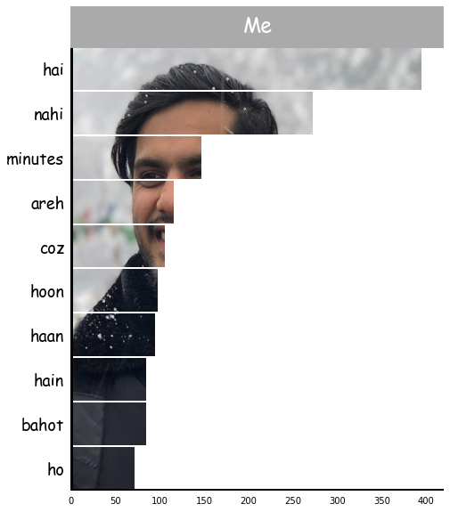

```python
tf_idf.plot_unique_words(unique_words, user='Me',
                         image_path='Nakul.jpg', image_url=None,
                         title="Me", title_color="white",
                         title_background='#AAAAAA', width=400, height=500)
```

## 4. Emoji Analysis

Back to Table of Contents

This analysis is based on the Emojis used in each message. Below you can find the following:

- Unique Emoji per user
- Commonly used Emoji per user
- Highly correlated Emoji per user

#### 4.1 Prepare Data

Back to Table of Contents

The data needs to be prepared as follows:

- Three new columns are created:
  - *Emoji* contains all emojis in a message
  - *Emoji_Counts* counts the number of emojis in a message
  - *Different_Emojis* extracts them in a list for handling purposes
- *counts* is a dictionary of dictionaries containing the count of each emoji per user
- *unique_emoji* is a dict of dicts containing a uniqueness score of each emoji per user compared to other users

```python
# https://github.com/pandas-dev/pandas/issues/17892
temp = df[['User', 'chat', 'Message_Only_Text']].copy()
temp = emoji.prepare_data(temp)
# Count all emojis
counts = emoji.count_emojis(temp, non_unicode=True)
# Get unique emojis
list_of_words = [word for user in counts for word in counts[user]]
unique_emoji = emoji.get_unique_emojis(temp, counts, list_of_words)
del temp
```

#### 4.2 Unique and Common Emoji

Back to Table of Contents

Below you can find the most unique emojis according to the TF-IDF and Unique formulas that were used previously:

**TF-IDF**

$ TFIDF_i = \frac{{t_{ij} + 1}}{w_i + 1} \times \log{\frac{m}{\sum_{i=1}^{n} t_j}} $  
$w_i = $ Number of words texted by $i$  
$t_{ij} = $ Number of times a specific emoji $j$ was said by $i$  
$m = $ Number of all messages

**Unique Emoji**

$ Unique_i = \frac{TFIDF_i}{\sum\limits_{j, j \neq i}^n TFIDF_i} $

I purposefully based it on the number of words and messages in total and only changed *t* to the number of times emoji was said

```python
emoji.print_stats(unique_emoji, counts)
```

```
#############################
### Unique Emoji (TF-IDF) ###
#############################

Me
:D 53.586942715610135
😓 22.96583259240438
😅 11.965391770832548

Her
😬 18.28803716608595
😞 11.887224157955867
😣 10.972822299651568

#########################
### Most Common Emoji ###
#########################

Me
😂 221
😅 185
🙈 133

Her
😂 165
😋 121
😭 103
```

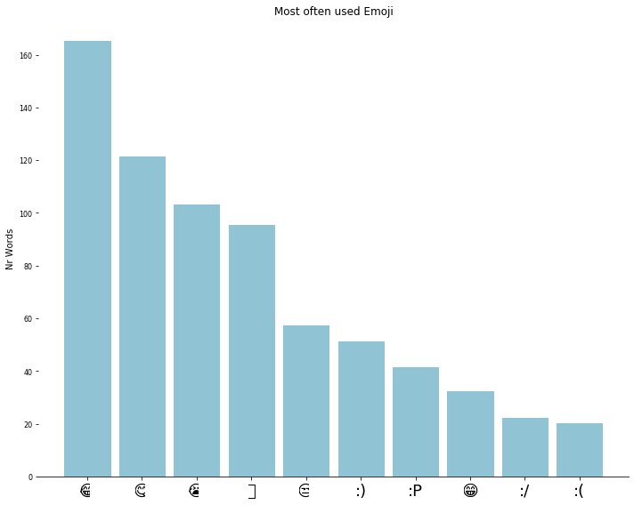

```python
emoji.plot_counts(counts, user = 'Her')
```

#### 4.3 Correlation Matrix

Back to Table of Contents

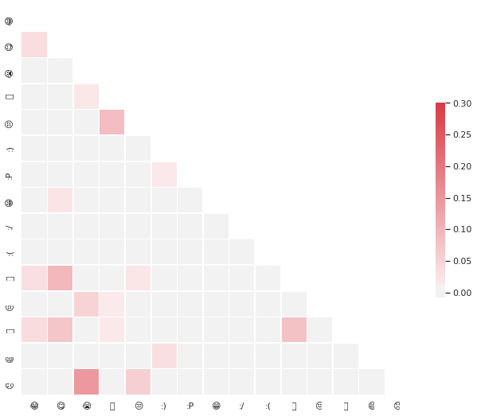

```python
emoji.plot_corr_matrix(df, 'Her', list_of_words, counts)
```

## 5. Sentiment

Back to Table of Contents

#### 5.1 Prepare Data

Back to Table of Contents

Currently, I have simply used NLTK's Vader for calculating sentiment of each message.

```python
df['sentiment'] = sentiment.calculate_sentiment(df)
```

#### 5.2 Average Sentiment Per User

Back to Table of Contents

Prints the average sentiment per user to get an indication of positivity of the user.

```python
sentiment.print_avg_sentiment(df)
```

```
			#######################
			## Average Sentiment ##
			#######################
Me:                           		0.032
Her:                          		0.033
```

#### 5.3 Plot Sentiment

Back to Table of Contents

Below you can see a plot of how positive the messages are over time. The y-axis works as follows, a happy smiley indicates a score of 1 (max value) meaning a positive message and a sad smiley indicates a score of -1 (min value) meaning a negative message.

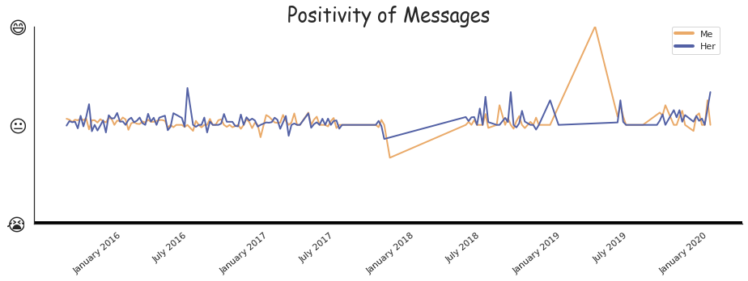

```python
sentiment.plot_sentiment(df, colors=['#EAAA69','#5361A5'], savefig=False)
```

## 6. Word Clouds

Back to Table of Contents

#### 6.1 Prepare Data

Back to Table of Contents

```python
# Counts words and create dictionary of words with counts
counts = tf_idf.count_words_per_user(df,sentence_column="chat",user_column="User")
counts = tf_idf.remove_stopwords(counts, path = "", file ='stopwords.txt', column="Word")
```

#### 6.2 Masked Word Cloud

Back to Table of Contents

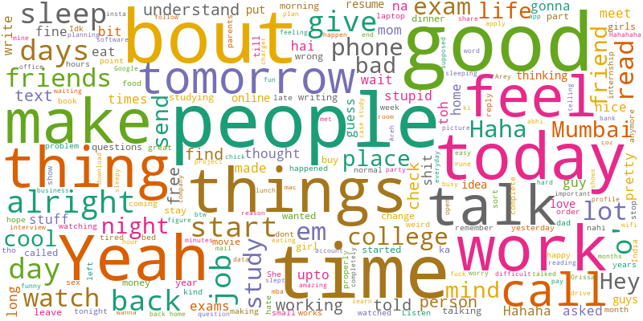

```python
wordcloud.create_wordcloud(df.chat, random_state = 42,
                           stopwords='stopwords.txt',
                           max_words=1000, max_font_size=50, scale=2,
                           normalize_plurals=False, relative_scaling = 0.5)
```

#### 6.3 Sentiment-based Word Cloud

Back to Table of Contents

*NOTE*: ONLY WORKS FOR DUTCH

```python
# Choose which user you want to see the word cloud for
positive, negative = wordcloud.extract_sentiment_count(counts, user = "Me")
```

##### Positive Words

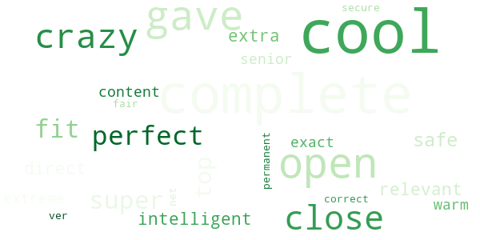

```python
wordcloud.create_wordcloud(data=positive, cmap='Greens',
                    stopwords='stopwords.txt', random_state=42, max_words=1000,
                    max_font_size=50, scale=1.5, normalize_plurals=False, relative_scaling=0.5)
```

##### Negative Words

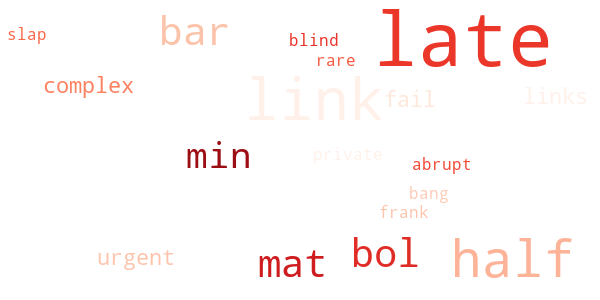

```python
wordcloud.create_wordcloud(data=negative, cmap='Reds',
                    stopwords='stopwords.txt', random_state=42, max_words=1000,
                    max_font_size=50, scale=1.5, normalize_plurals=False, relative_scaling=0.5)
```